# 6.6 Task Analyzing Time Series Data_IP

## 6.6: Sourcing & Analyzing Time Series Data

This script includes the following topics,

```
I.   Install and import libraries and dataset
II.  Time series analysis
III.  Testing for stationarit
IV. Stationarizing c Data
```

### I. Install and import libraries and dataset

```python
import quandl
import pandas as pd
import numpy as np
import seaborn as sns
import matplotlib
import matplotlib.pyplot as plt
import statsmodels.api as sm # Using .api imports the public access version of statsmodels, which is a library that handles
# statistical models.
import os
import warnings # This is a library that handles warnings.

warnings.filterwarnings("ignore") # Disable deprecation warnings that could indicate, for instance, a suspended library or
# feature. These are more relevant to developers and very seldom to analysts.

plt.style.use('fivethirtyeight') # This is a styling option for how your plots will appear. More examples here:
# https://matplotlib.org/3.2.1/tutorials/introductory/customizing.html
# https://matplotlib.org/3.1.0/gallery/style_sheets/fivethirtyeight.html
```

```python
# Create path

path = r'C:\Users\inesh\Documents\Learning\CF_Data Analytics course\Data Analytics Immesion\Achievement 6\Hotel Booking Data Analysis'
```

```python
# Importing the cleaned dataset

df_hotel_cleaned = pd.read_pickle(os.path.join(path, 'II. Data Set', 'Prepared Data', 'df_hotel_cleaned_6.2.pkl'))
```

```python
df_hotel_cleaned.head()
```

|  | Booking ID | Date of Booking | Time | Customer ID | Gender | Age | customer_origin_country | State | City | Destination Country | ... | No. Of People | Check-in date | Number_of_days_booked | No_of_rooms_booked | Hotel Name | Hotel Rating | Total_booking_Price_SG$ | Profit Margin | Room_price_per_day_SG$ | Price Category |
| --- | --- | --- | --- | --- | --- | --- | --- | --- | --- | --- | --- | --- | --- | --- | --- | --- | --- | --- | --- | --- | --- |
| 0 | DDMY00001 | 2010-01-01 | 2024-03-04 10:49:40 | MY00001 | Male | 42 | Malaysia | Johor | Iskandar Puteri | Denmark | ... | 1 | 2010-01-12 | 8 | 1 | Hotel Triton | 4.3 | 243 | 0.25 | 243.000000 | Mid Price |
| 1 | DDID00002 | 2010-01-01 | 2024-03-04 09:19:47 | ID00001 | Female | 44 | Indonesia | Ciawi | West Java | Colombia | ... | 3 | 2010-01-21 | 1 | 2 | Enchanted Isle | 4.2 | 312 | 0.24 | 156.000000 | Mid Price |
| 2 | DDSG00003 | 2010-01-01 | 2024-03-04 11:52:56 | SG00001 | Female | 31 | Singapore | Central | Rochor | Germany | ... | 3 | 2010-01-02 | 7 | 2 | Seacoast Hotel | 4.5 | 338 | 0.20 | 169.000000 | Mid Price |
| 3 | DDSG00004 | 2010-01-01 | 2024-03-04 13:44:40 | SG00002 | Male | 28 | Singapore | North | Yishun | Canada | ... | 3 | 2010-02-15 | 4 | 2 | Night In Paradise | 4.2 | 254 | 0.13 | 127.000000 | Low Price |
| 4 | DDKH00005 | 2010-01-01 | 2024-03-04 05:38:26 | KH00001 | Male | 44 | Cambodia | Phnom Trop | Pursat | Kenya | ... | 5 | 2010-01-03 | 3 | 3 | Tiny Digs Hotel | 4.6 | 313 | 0.17 | 104.333333 | Low Price |

5 rows × 21 columns

```python
df_hotel_cleaned.shape
```

```
(66536, 21)
```

```python
df_hotel_cleaned.columns
```

```
Index(['Booking ID', 'Date of Booking', 'Time', 'Customer ID', 'Gender', 'Age',
       'customer_origin_country', 'State', 'City', 'Destination Country',
       'Destination City', 'No. Of People', 'Check-in date',
       'Number_of_days_booked', 'No_of_rooms_booked', 'Hotel Name',
       'Hotel Rating', 'Total_booking_Price_SG$', 'Profit Margin',
       'Room_price_per_day_SG$', 'Price Category'],
      dtype='object')
```

```python
df_hotel_cleaned.info()
```

```
<class 'pandas.core.frame.DataFrame'>
Index: 66536 entries, 0 to 66540
Data columns (total 21 columns):
 #   Column                   Non-Null Count  Dtype
---  ------                   --------------  -----
 0   Booking ID               66536 non-null  object
 1   Date of Booking          66536 non-null  datetime64[ns]
 2   Time                     66536 non-null  datetime64[ns]
 3   Customer ID              66536 non-null  object
 4   Gender                   66536 non-null  object
 5   Age                      66536 non-null  int64
 6   customer_origin_country  66536 non-null  object
 7   State                    66536 non-null  object
 8   City                     66536 non-null  object
 9   Destination Country      66536 non-null  object
 10  Destination City         66536 non-null  object
 11  No. Of People            66536 non-null  int64
 12  Check-in date            66536 non-null  datetime64[ns]
 13  Number_of_days_booked    66536 non-null  int64
 14  No_of_rooms_booked       66536 non-null  int64
 15  Hotel Name               66536 non-null  object
 16  Hotel Rating             66536 non-null  float64
 17  Total_booking_Price_SG$  66536 non-null  int64
 18  Profit Margin            66536 non-null  float64
 19  Room_price_per_day_SG$   66536 non-null  float64
 20  Price Category           66536 non-null  object
dtypes: datetime64[ns](3), float64(3), int64(5), object(10)
memory usage: 11.2+ MB
```

```python
## Check for null values

null_values = df_hotel_cleaned['Date of Booking'].isnull().sum()
```

```python
null_values
```

```
0
```

#### Create a data subset using Date of booking column & Room_price_per_day_SG$. Room Price per day is a created column dividing Total_booking_Price by Number_of_days_booked )

```python
# Create a subset of the Date of Booking and  Room_price_per_day_SG$

subset_columns = ['Date of Booking', 'Room_price_per_day_SG$']

# Create a subset DataFrame with selected columns
subset_df = df_hotel_cleaned[subset_columns]
```

```python
subset_df
```

|  | Date of Booking | Room_price_per_day_SG$ |
| --- | --- | --- |
| 0 | 2010-01-01 | 243.000000 |
| 1 | 2010-01-01 | 156.000000 |
| 2 | 2010-01-01 | 169.000000 |
| 3 | 2010-01-01 | 127.000000 |
| 4 | 2010-01-01 | 104.333333 |
| ... | ... | ... |
| 66536 | 2019-12-31 | 91.000000 |
| 66537 | 2019-12-31 | 62.500000 |
| 66538 | 2019-12-31 | 79.500000 |
| 66539 | 2019-12-31 | 86.500000 |
| 66540 | 2019-12-31 | 60.666667 |

66536 rows × 2 columns

```python
## Creating a subset from the average price of Room per Day from all identical dates to remove duplicate dates

average_price_df = subset_df.groupby('Date of Booking')['Room_price_per_day_SG$'].mean().reset_index()
```

```python
average_price_df
```

|  | Date of Booking | Room_price_per_day_SG$ |
| --- | --- | --- |
| 0 | 2010-01-01 | 121.035714 |
| 1 | 2010-01-02 | 116.116667 |
| 2 | 2010-01-03 | 106.769231 |
| 3 | 2010-01-04 | 196.010417 |
| 4 | 2010-01-05 | 137.398148 |
| ... | ... | ... |
| 3647 | 2019-12-27 | 127.629032 |
| 3648 | 2019-12-28 | 115.692857 |
| 3649 | 2019-12-29 | 120.966667 |
| 3650 | 2019-12-30 | 158.562500 |
| 3651 | 2019-12-31 | 123.663333 |

3652 rows × 2 columns

```python
## Create monthly average price of a room per day dataset

average_price_monthly_df = average_price_df.groupby(average_price_df['Date of Booking'].dt.to_period('M'))['Room_price_per_day_SG$'].mean().reset_index()
```

```python
average_price_monthly_df
```

|  | Date of Booking | Room_price_per_day_SG$ |
| --- | --- | --- |
| 0 | 2010-01 | 125.079612 |
| 1 | 2010-02 | 115.447046 |
| 2 | 2010-03 | 116.446656 |
| 3 | 2010-04 | 116.882105 |
| 4 | 2010-05 | 115.247684 |
| ... | ... | ... |
| 115 | 2019-08 | 124.243463 |
| 116 | 2019-09 | 138.947332 |
| 117 | 2019-10 | 132.852743 |
| 118 | 2019-11 | 130.371416 |
| 119 | 2019-12 | 127.266114 |

120 rows × 2 columns

```python
average_price_monthly_df.info()
```

```
<class 'pandas.core.frame.DataFrame'>
RangeIndex: 120 entries, 0 to 119
Data columns (total 2 columns):
 #   Column                  Non-Null Count  Dtype
---  ------                  --------------  -----
 0   Date of Booking         120 non-null    period[M]
 1   Room_price_per_day_SG$  120 non-null    float64
dtypes: float64(1), period[M](1)
memory usage: 2.0 KB
```

```python
## Create an Index in average_price_monthly_df using Date of Booking

average_price_monthly_df.set_index('Date of Booking', inplace=True)
```

```python
average_price_monthly_df
```

| Date of Booking | Room_price_per_day_SG$ |
| --- | --- |
| 2010-01 | 125.079612 |
| 2010-02 | 115.447046 |
| 2010-03 | 116.446656 |
| 2010-04 | 116.882105 |
| 2010-05 | 115.247684 |
| ... | ... |
| 2019-08 | 124.243463 |
| 2019-09 | 138.947332 |
| 2019-10 | 132.852743 |
| 2019-11 | 130.371416 |
| 2019-12 | 127.266114 |

120 rows × 1 columns

```python
average_price_monthly_df.info()
```

```
<class 'pandas.core.frame.DataFrame'>
PeriodIndex: 120 entries, 2010-01 to 2019-12
Freq: M
Data columns (total 1 columns):
 #   Column                  Non-Null Count  Dtype
---  ------                  --------------  -----
 0   Room_price_per_day_SG$  120 non-null    float64
dtypes: float64(1)
memory usage: 1.9 KB
```

```python
##Checking for missing values

average_price_monthly_df.isnull().sum()
```

```
Room_price_per_day_SG$    0
dtype: int64
```

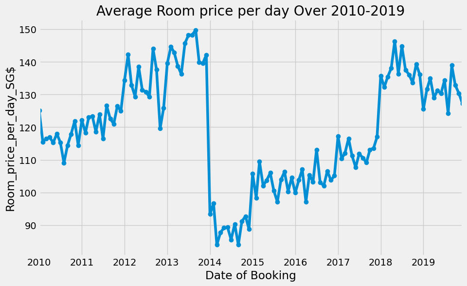

```python
import matplotlib.pyplot as plt

# Plot the data
plt.figure(figsize=(10, 6))

# Plot the data
plt.plot(average_price_monthly_df.index, average_price_monthly_df['Room_price_per_day_SG$'], marker='o', linestyle='-')
plt.title('Average Room price per day Over 2010-2019')
plt.xlabel('Date of Booking')
plt.ylabel('Room_price_per_day_SG$')
plt.grid(True)

# Set x-axis limits to start from 2010
plt.xlim(pd.Timestamp('2010-01-01'), average_price_monthly_df.index.max())

plt.show()
```

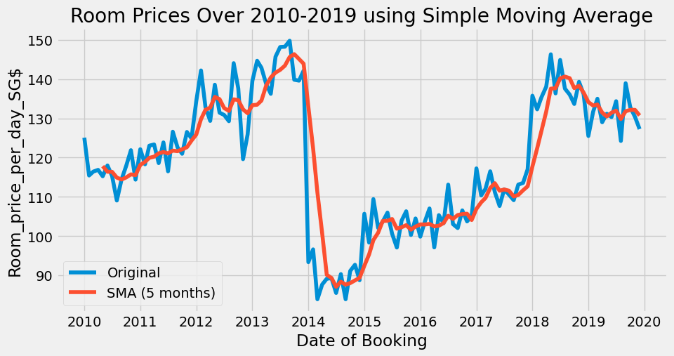

```python
# Simple Moving Average (SMA) of Room_price_per_day_SG$

window_size = 5  # Adjust the window size as needed
sma = average_price_monthly_df['Room_price_per_day_SG$'].rolling(window=window_size).mean()

# Plotting the original and smoothed data
plt.figure(figsize=(10, 5))
plt.plot(average_price_monthly_df['Room_price_per_day_SG$'], label='Original')
plt.plot(sma, label=f'SMA ({window_size} months)')
plt.title('Room Prices Over 2010-2019 using Simple Moving Average')
plt.xlabel('Date of Booking')
plt.ylabel('Room_price_per_day_SG$')
plt.legend()
plt.show()
```

#### simple moving average for 5 months shows the data set with less noise

```python
sma = average_price_monthly_df['Room_price_per_day_SG$'].rolling(window=10).mean()

# Drop rows with missing values
sma = sma.dropna()
```

## II. Time series analysis

#### Decomposition

```python
## Decompose the time series using an additive model

decomposition = sm.tsa.seasonal_decompose(sma, model='additive')
```

```python
from pylab import rcParams # To fixed size for all special charts.

rcParams['figure.figsize'] = 18, 7
```

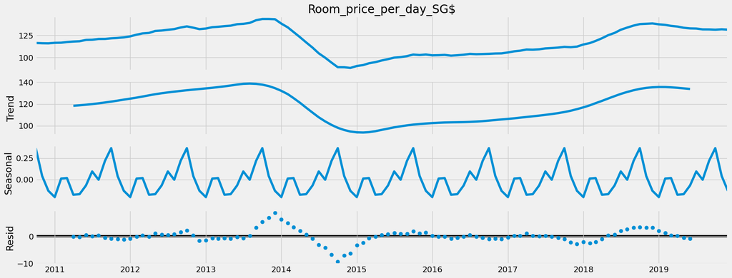

```python
# Plot the separate components

decomposition.plot()
plt.show()
```

#### It appears that the overall trend indicates an increase in the price per room per day, even though a significant drop between 2014 and 2015. Following 2019, there seems to be a gradual decline once again. Also there are clear seasonalities in the chart

## III. Testing for stationarit

```python
## dickey_fuller test for smoothned data

from statsmodels.tsa.stattools import adfuller

result = adfuller(sma)  # Perform the test on the SMA series
print("ADF Statistic:", result[0])
print("p-value:", result[1])
print("Critical Values:", result[4])
```

```
ADF Statistic: -2.6545162548605488
p-value: 0.08224500896415199
Critical Values: {'1%': -3.4996365338407074, '5%': -2.8918307730370025, '10%': -2.5829283377617176}
```

ADF Statistic: -2.6545162548605488 In this case, the value of the statistic is negative, indicating that the data might be stationary

Critical Values: {'1%': -3.4996365338407074, '5%': -2.8918307730370025, '10%': -2.5829283377617176} ADF statistic is more negative than these critical values, therefore the null hypothesis can reject with the corresponding level of confidence. But here ADF statistic is not more negative than the critical values at the typical significance levels..

#### Here data can be concluded as not stationary

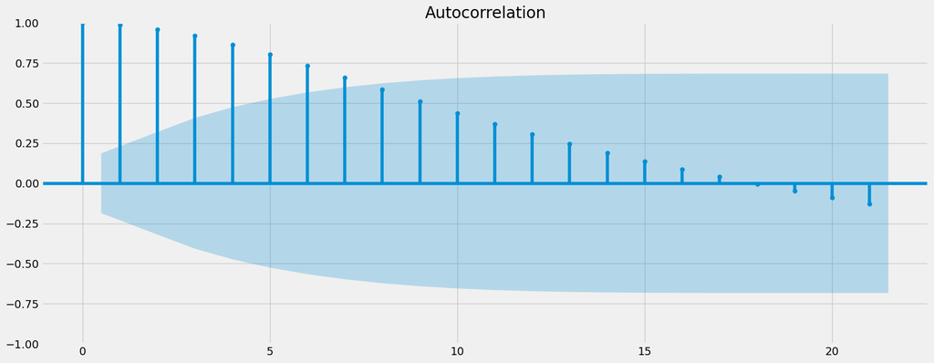

```python
# Check out a plot of autocorrelations

from statsmodels.graphics.tsaplots import plot_acf, plot_pacf # import the autocorrelation and partial correlation plots

plot_acf(sma)
plt.show()
```

##### around 33% of all data are outside the significant area, firther stationarisation needs for data set

## IV Stationarizing data

```python
data_diff = sma - sma.shift(1) # The df.shift(1) function turns the observation to t-1, making the whole thing t - (t -1)
```

```python
 # Remove the missing values that came about as a result of the differencing to run the Dickey-Fuller test.
data_diff.dropna(inplace = True)
```

```python
data_diff.head()
```

```
Date of Booking
2010-11-01   -0.318549
2010-12-01   -0.106233
2011-01-01    0.569128
2011-02-01    0.141643
2011-03-01    0.779533
Freq: MS, Name: Room_price_per_day_SG$, dtype: float64
```

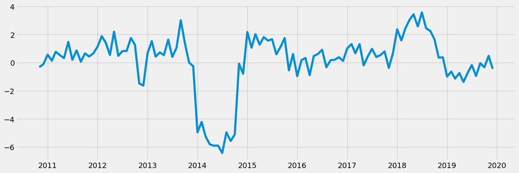

```python
# Check out what the differencing did to the time-series curve

plt.figure(figsize=(15,5), dpi=100)
plt.plot(data_diff)
```

```python
from statsmodels.tsa.stattools import adfuller

result = adfuller(data_diff)
```

```python
## dickey_fuller test for smoothned data

from statsmodels.tsa.stattools import adfuller

result = adfuller(data_diff)
print("ADF Statistic:", result[0])
print("p-value:", result[1])
print("Critical Values:", result[4])
```

```
ADF Statistic: -1.6972437476094748
p-value: 0.4325331376461031
Critical Values: {'1%': -3.4996365338407074, '5%': -2.8918307730370025, '10%': -2.5829283377617176}
```

#### Data set still shows non-stationary behavior

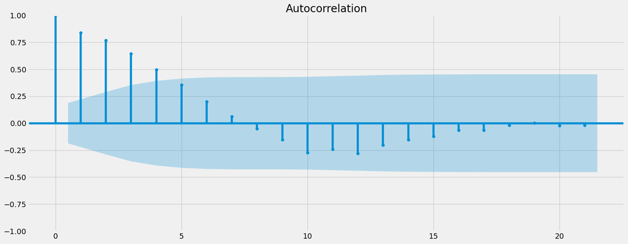

```python
plot_acf(data_diff)
plt.show()
```

```python
## Second round statioanarizing data

data_diff_1 = data_diff - data_diff.shift(1) # The df.shift(1) function turns the observation to t-1, making the whole thing t - (t -1)
```

```python
## Remove the missing values that came about as a result of the differencing to remove these or you won't be able to run the Dickey-Fuller test.
data_diff_1.dropna(inplace = True)
```

```python
data_diff_1.head()
```

```
Date of Booking
2010-12-01    0.212316
2011-01-01    0.675361
2011-02-01   -0.427485
2011-03-01    0.637891
2011-04-01   -0.244441
Freq: MS, Name: Room_price_per_day_SG$, dtype: float64
```

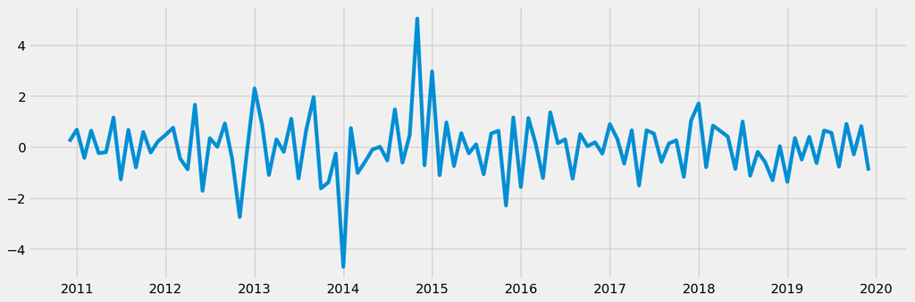

```python
plt.figure(figsize=(15,5), dpi=100)
plt.plot(data_diff_1)
```

```python
from statsmodels.tsa.stattools import adfuller

#  data_diff_1 contains  differenced data
result = adfuller(data_diff_1)

# Print the ADF Statistic, p-value, and Critical Values
print("ADF Statistic:", result[0])
print("p-value:", result[1])
print("Critical Values:", result[4])
```

```
ADF Statistic: -5.391237881066044
p-value: 3.533733255825787e-06
Critical Values: {'1%': -3.4996365338407074, '5%': -2.8918307730370025, '10%': -2.5829283377617176}
```

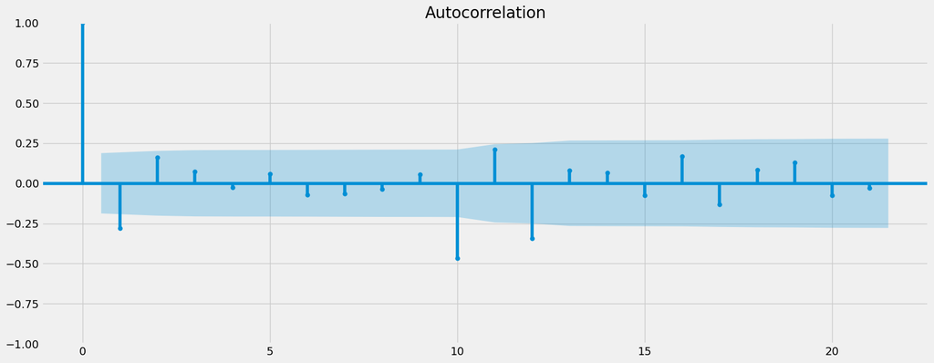

```python
plot_acf(data_diff_1)
plt.show()
```

#### According to Dickeyfuller test and autocorrelation chart dataset is stationary